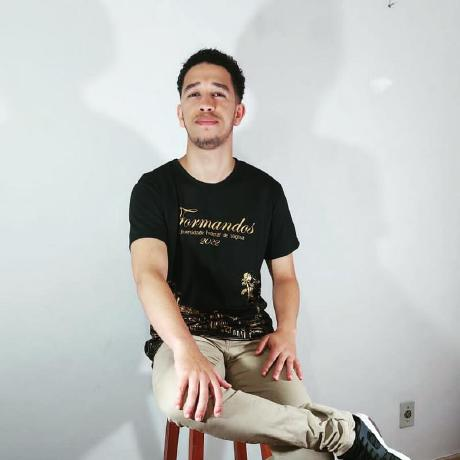

# Olá, meu nome é Lucas Pereira Belo 👋

*Atualmente sou doutorando em Estatística Aplicada e Biometria pela **UFV**, com foco em Análise de Sobrevivência e Séries Temporais. Buscando oportunidades para aplicar minhas habilidades analíticas desenvolvidas durante a graduação e mestrado, para resolver problemas complexos na área de dados.*

## 🛠️ Ferramentas e Tecnologias

[figure not shown]

## 🚀 Áreas de Atuação e Projetos Destaque

**⚽ Estatística Aplicada ao Futebol**

### Modelagem da Diferença de Gols no Campeonato Brasileiro

Análise da diferença de gols entre mandantes e visitantes por rodada, com ajuste e comparação de distribuições discretas, incluindo Normal discreta, skew-normal discreta, Skellam e diferença Weibull discreta.

**Tecnologias:** R, R Markdown, máxima verossimilhança, AIC, BIC.

[**Ver Análise Completa →**](https://Lucasbpofc.github.io/Brasileirao/analise_distribuicoes_brasileirao.html)

**📈 Séries Temporais**

### Preços do Café Arábica

Análise da volatilidade condicional dos preços do café arábica utilizando modelos da família ARCH/GARCH.

**Tecnologias:** R, Tidyverse, GARCH.

[**Ver Análise Completa →**](https://Lucasbpofc.github.io/Post_caféarabica.html)

### Preços da Soja

Modelagem da volatilidade dos preços da soja utilizando o modelo APARCH.

**Status:** Em desenvolvimento 🚧

**⛈️ Teoria de Valores Extremos (GEV)**

### Precipitação Máxima - Lavras/MG

Modelagem da precipitação máxima esperada utilizando a Distribuição Generalizada de Valores Extremos (GEV) para estimar períodos de retorno de eventos climáticos.

**Tecnologias:** R, GEV, Análise de Dados Climáticos.

[figure not shown]

### Extremos Climáticos - Viçosa/MG

Análise de precipitação e temperaturas extremas na cidade de Viçosa.

**Tecnologias:** R, extRemes, ismev, GEV.

[**Ver Análise Completa →**](https://Lucasbpofc.github.io/TESE/VICOSA_MD.html)

### Extremos Climáticos - Teófilo Otoni/MG

Análise de frequência de precipitações máximas diárias e estimativa de tempos de retorno utilizando a Distribuição GEV.

**Tecnologias:** R, extRemes, goftest, TVE.

[**Ver Análise Completa →**](https://Lucasbpofc.github.io/TESE/Teofilo_Otoni.html)

**⏳ Análise de Sobrevivência**

### Estudo de Mecanismos de Censura

Uma exploração teórica e prática dos diferentes tipos de censura e suas implicações em estudos de sobrevivência.

**Tecnologias:** R, Survival, ggplot2.

[**Ver Análise Completa →**](https://Lucasbpofc.github.io/Mecanismos-de-Censura.html)

[output not shown]

**🧹 Manipulação e Limpeza de Dados**

### Estudo do Pacote Forcats

Tutorial prático sobre a manipulação de variáveis categóricas (fatores) no R utilizando o poderoso pacote Forcats, parte do Tidyverse.

**Tecnologias:** R, Tidyverse, Forcats.

[**Ver Análise Completa →**](https://Lucasbpofc.github.io/Pacote-forcats.html)

**🤖 Aprendizado de Máquina**

### Seleção de Famílias Pró-Produtivas de Cana-de-Açúcar

Projeto final (EST792) focando na aplicação de algoritmos de Machine Learning para a seleção de famílias de cana-de-açúcar com alto potencial produtivo.

**Tecnologias:** R, Machine Learning, R Markdown.

[**Ver Relatório Completo →**](https://Lucasbpofc.github.io/Machine_Learning/HW6_Blessing_Inacio_Lucas_Rodrigo.html)

## 🎓 Apresentações Acadêmicas

[figure not shown]

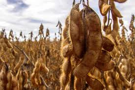

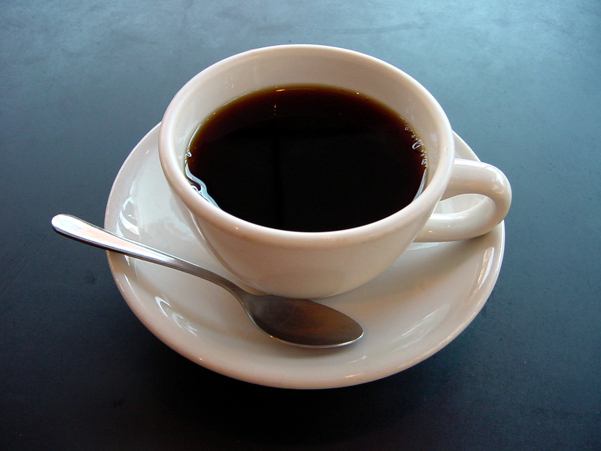

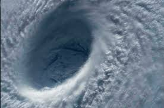

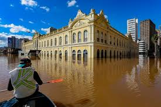

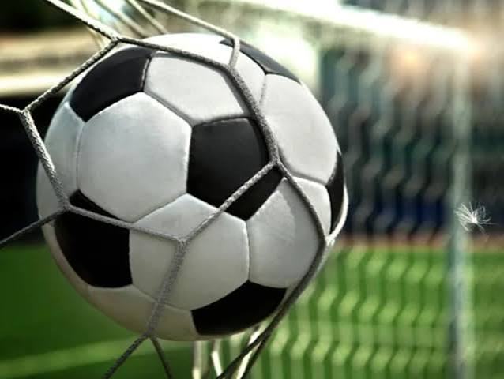

## 🔥 Minhas Estatísticas no GitHub

[figure not shown]

⚡ **Curiosidade:** Ligeiramente apaixonado pelo Vasco da Gama, gosto de jogar xadrez e me aprofundar em séries temporais!

## 📫 Entre em Contato

[figure not shown]

## 🐍 Minhas Contribuições

[figure not shown]